# Applied Statistics Project

```python
import numpy as np
import pandas as pd
import scipy.stats as stats
import matplotlib.pyplot as plt
import seaborn as sns
%matplotlib inline
```

## Part One - Question Based

**1. Question**: Please refer the table below to answer below questions:

| Planned to purchase product A | Actually placed an order for Product A-Yes | Actually placed an order for Product A-NO | Total |
| --- | --- | --- | --- |
| Yes | 400 | 100 | 500 |
| No | 200 | 1300 | 1500 |
| Total | 600 | 1400 | 2000 |

1. Refer to the above table and find the joint probability of the people who planned to purchase and actually placed an order.
2. Refer to the above table and find the joint probability of the people who planned to purchase and actually placed an order, given that people planned to purchase.

   **Solution** : 1. **P**(Planned to purchase **and** Placed an order for Product A)= 400/2000 = 0.2 = 20%  
   2. **P** (Planned to purchase and actually placed an order **given** people planned to purchase) =  
   P (Planned to purchase and actually placed an order ) / P ( Planned to purchase ) = (400/2000)/(500/2000) =400/500 =0.8 = 80%

```python
p1 =400/2000
print(p1*100)
p2 = 400/500
print(p2*100)
```

```
20.0
80.0
```

**2. Question** : An electrical manufacturing company conducts quality checks at specified periods on the products it manufactures. Historically, the failure rate for the manufactured item is 5%. Suppose a random sample of 10 manufactured items is selected. Answer the following questions.  
A. Probability that none of the items are defective?  
B. Probability that exactly one of the items is defective?  
C. Probability that two or fewer of the items are defective?  
D. Probability that three or more of the items are defective ?

**Solution** : The given problem can be solved using binomial distribution where *n = 10*

Probablity of being defective = *P = 0.05*

Probablity of not being defective = *1-P = 0.95*

```python
N1 = 10
P1 =0.05
number_of_defects =np.arange(0,10)
binomial = stats.binom.pmf(number_of_defects,N1,P1)
print(" A. Probablity that none of the items are defective is =", binomial[0].round(3)*100, "%")
print(" B. Probability that exactly one of the items is defective is =", binomial[1].round(3)*100, "%")
print(" C. Probability that two or fewer of the items are defective is =", (binomial[0]+binomial[1]+binomial[2]).round(4)*100, "%")
print(" D. Probability that three or more of the items are defective is =", (1-(binomial[0]+binomial[1]+binomial[2])).round(4)*100, "%")

#plt.plot(number_of_defects,binomial,'o-')
#plt.title('Binomial: N=%i , P=%.2f' % (N1,P1), fontsize=15)
#plt.xlabel('Number of Defective items')
#plt.ylabel('Probability of item being defective')
#plt.show()
```

```
 A. Probablity that none of the items are defective is = 59.9 %
 B. Probability that exactly one of the items is defective is = 31.5 %
 C. Probability that two or fewer of the items are defective is = 98.85000000000001 %
 D. Probability that three or more of the items are defective is = 1.15 %
```

**3 Question**: A car salesman sells on an average 3 cars per week.  
A. Probability that in a given week he will sell some cars.  
B. Probability that in a given week he will sell 2 or more but less than 5 cars.  
C. Plot the poisson distribution function for cumulative probability of cars sold per-week vs number of cars sold perweek.  
**Solution** : The given problem can be solved using Poisson distribution where **lambda = 3**  
A. Probability that in a given week he will sell some cars means he sells more than 1 car ie *P(X>=1) = 1 - P(X=0) = 95.02 %*  
B. Probability that in a given week he will sell 2 or more but less than 5 cars = *P(2<=X<5) = P(X=2)+P(X=3)+P(X=4) = 61.61 %*

```
 A. Probability that in a given week he will sell some cars means he sells more than 1 car ie P(X>=1) = 1 - P(X=0) = 95.02000000000001 %
 B. Probability that in a given week he will sell 2 or more but less than 5 cars = P(2<=X<5) = 61.61 %
C. Plot the poisson distribution function for cumulative probability of cars sold per-week vs number of cars sold perweek
```

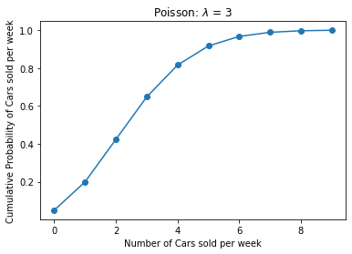

```python
rate=3
A = stats.poisson.pmf(0,rate)
B = 1-A
C = stats.poisson.pmf(2,rate)
D = stats.poisson.pmf(3,rate)
E = stats.poisson.pmf(4,rate)
F = C+D+E
n=np.arange(0,10) #Assuming that he sells 20 cars per week to set an upper bound.
poisson = stats.poisson.cdf(n,rate)
print(" A. Probability that in a given week he will sell some cars means he sells more than 1 car ie P(X>=1) = 1 - P(X=0) =", B.round(4)*100,"%")
print(" B. Probability that in a given week he will sell 2 or more but less than 5 cars = P(2<=X<5) =", F.round(4)*100,"%")
print("C. Plot the poisson distribution function for cumulative probability of cars sold per-week vs number of cars sold perweek")
plt.plot(n,poisson,'o-')
plt.title('Poisson: $\lambda$ = %i ' % rate)
plt.xlabel('Number of Cars sold per week')
plt.ylabel('Cumulative Probability of Cars sold per week')
plt.show()
```

**4. Question**: Accuracy in understanding orders for a speech based bot at a restaurant is important for the Company X which has designed, marketed and launched the product for a contactless delivery due to the COVID-19 pandemic. Recognition accuracy that measures the percentage of orders that are taken correctly is 86.8%. Suppose that you place order with the bot and two friends of yours independently place orders with the same bot. Answer the following questions.  
A. What is the probability that all three orders will be recognised correctly?  
B. What is the probability that none of the three orders will be recognised correctly?  
C. What is the probability that at least two of the three orders will be recognised correctly?  
**Solution** : The above problem can be solved using Binomial Distribution where **n=3**

Probablity of taking correct order = **P = 86.8% = 0.868**

Probablity of taking incorrect order = **1-P =13.2% = 0.132**

A. What is the probability that all three orders will be recognised correctly? = **65.4%**

B. What is the probability that none of the three orders will be recognised correctly?= **0.22%**

C. What is the probability that at least two of the three orders will be recognised correctly? = **95.23%**

```python
N2 = 3
P2 = 0.868
number_of_orders =np.arange(0,4)
binomial = stats.binom.pmf(number_of_orders,N2,P2)
print(binomial)
print(" A. Probablity that all three orders will be recognised correctly is =", binomial[3].round(3)*100, "%")
print(" B. Probablity none of the three orders will be recognised correctly is =", binomial[0].round(4)*100, "%")
print(" C. Probablity that at least two of the three orders will be recognised correctly is =", (1-(binomial[0]+binomial[1])).round(4)*100, "%")
#or
cumbinomial = stats.binom.cdf(number_of_orders,N2,P2)
P = 1 - cumbinomial[1]
print(" C. Probablity that at least two of the three orders will be recognised correctly is = %1.4f" % P)
```

```
[0.00229997 0.0453721  0.2983559  0.65397203]
 A. Probablity that all three orders will be recognised correctly is = 65.4 %
 B. Probablity none of the three orders will be recognised correctly is = 0.22999999999999998 %
 C. Probablity that at least two of the three orders will be recognised correctly is = 95.23 %
 C. Probablity that at least two of the three orders will be recognised correctly is = 0.9523
```

**5. Question**: A group of 300 professionals sat for a competitive exam. The results show the information of marks obtained by them have a mean of 60 and a standard deviation of 12. The pattern of marks follows a normal distribution. Answer the following questions.  
A. What is the percentage of students who score more than 80.  
B. What is the percentage of students who score less than 50.  
C. What should be the distinction mark if the highest 10% of students are to be awarded distinction?  
**Solution** : Given that the pattern mark follows a normal distribution with **Mean = 60** and **Standard Deviation=12**

A. Percentage of students who score more than 80 is = 4.77903522728147 %

B. Percentage of students who score less than 50 is = 20.232838096364308 %  
C. The distinction mark if the highest 10% of students are to be awarded distinction = 75.384  
For 10% distinction mark z = 1.282 ie P ( z > 1.282 ) = 0.1

```python
mean1 = 60
var1=12
morethan80 = 1-stats.norm.cdf(80,loc=mean1,scale=var1)
print("A. Percentage of students who score more than 80 is =",morethan80*100,"%")
lessthan50= stats.norm.cdf(50,loc=mean1,scale=var1)
print("B. Percentage of students who score less than 50 is =",lessthan50*100,"%")
distinction_mark = 1.282 * var1 + 60
print("C. The distinction mark if the highest 10% of students are to be awarded distinction =",distinction_mark)
```

```
A. Percentage of students who score more than 80 is = 4.77903522728147 %
B. Percentage of students who score less than 50 is = 20.232838096364308 %
C. The distinction mark if the highest 10% of students are to be awarded distinction = 75.384
```

**6. Question**: Explain 1 real life industry scenario where you can use the concepts learnt in this module of Applied statistics to get a data driven business solution.  
**Solution** : **Social Media** is growing at an unprecedented rate, and thus is one of the most demanding real life industry where Statisical tools can be used. Social media influencers can keep track of how much engagment and retainment is there based on the data that is generated via the apps such as Instagram and Youtube Studio. The number of likes and views can be used to find out what kind of content is being liked by the viewers and inturn used as feedback to create similar type of content to get higher engagment for their particular handles / channels etc. If one looks for there is a tremendous amount of data that can be used as information with proper handling. For example : The probablity of a user responding to a post follows a Binomial distribution, which can be used to find out how many people will see a post etc, with this information one can know how to proceed further to increase business outcomes.

# Part - 2 Project Based

**DOMAIN: Sports**  
**• CONTEXT**: Company X manages the men's top professional basketball division of the American league system.The dataset contains information on all the teams that have participated in all the past tournaments. It has data about how many baskets each team scored, conceded, how many times they came within the first 2 positions, how many tournaments they have qualified, their best position in the past, etc.

**• DATA DESCRIPTION:** Basketball.csv - The data set contains information on all the teams so far participated in all the past tournaments.  
**• ATTRIBUTE INFORMATION:**  
1. Team: Team’s name  
2. Tournament: Number of played tournaments.  
3. Score: Team’s score so far.  
4. PlayedGames: Games played by the team so far.  
5. WonGames: Games won by the team so far.  
6. DrawnGames: Games drawn by the team so far.  
7. LostGames: Games lost by the team so far.  
8. BasketScored: Basket scored by the team so far.  
9. BasketGiven: Basket scored against the team so far.  
10. TournamentChampion: How many times the team was a champion of the tournaments so far.  
11. Runner-up: How many times the team was a runners-up of the tournaments so far.  
12. TeamLaunch: Year the team was launched on professional basketball.  
13. HighestPositionHeld: Highest position held by the team amongst all the tournaments played.  
**PROJECT OBJECTIVE:** Company’s management wants to invest on proposal on managing some of the best teams in the league. The analytics department has been assigned with a task of creating a report on the performance shown by the teams. Some of the older teams are already in contract with competitors. Hence Company X wants to understand which teams they can approach which will be a deal win for them.

## 1. Read the data set, clean the data and prepare a final dataset to be used for analysis.**

```python
basketball_orignal = pd.read_csv('Basketball.csv')
```

```python
basketball_orignal.head()
```

|  | Team | Tournament | Score | PlayedGames | WonGames | DrawnGames | LostGames | BasketScored | BasketGiven | TournamentChampion | Runner-up | TeamLaunch | HighestPositionHeld |
| --- | --- | --- | --- | --- | --- | --- | --- | --- | --- | --- | --- | --- | --- |
| 0 | Team 1 | 86 | 4385 | 2762 | 1647 | 552 | 563 | 5947 | 3140 | 33 | 23 | 1929 | 1 |
| 1 | Team 2 | 86 | 4262 | 2762 | 1581 | 573 | 608 | 5900 | 3114 | 25 | 25 | 1929 | 1 |
| 2 | Team 3 | 80 | 3442 | 2614 | 1241 | 598 | 775 | 4534 | 3309 | 10 | 8 | 1929 | 1 |
| 3 | Team 4 | 82 | 3386 | 2664 | 1187 | 616 | 861 | 4398 | 3469 | 6 | 6 | 1931to32 | 1 |
| 4 | Team 5 | 86 | 3368 | 2762 | 1209 | 633 | 920 | 4631 | 3700 | 8 | 7 | 1929 | 1 |

```python
basketball_orignal.tail()
```

|  | Team | Tournament | Score | PlayedGames | WonGames | DrawnGames | LostGames | BasketScored | BasketGiven | TournamentChampion | Runner-up | TeamLaunch | HighestPositionHeld |
| --- | --- | --- | --- | --- | --- | --- | --- | --- | --- | --- | --- | --- | --- |
| 56 | Team 57 | 1 | 34 | 38 | 8 | 10 | 20 | 38 | 66 | - | - | 2009-10 | 20 |
| 57 | Team 58 | 1 | 22 | 30 | 7 | 8 | 15 | 37 | 57 | - | - | 1956-57 | 16 |
| 58 | Team 59 | 1 | 19 | 30 | 7 | 5 | 18 | 51 | 85 | - | - | 1951~52 | 16 |
| 59 | Team 60 | 1 | 14 | 30 | 5 | 4 | 21 | 34 | 65 | - | - | 1955-56 | 15 |
| 60 | Team 61 | 1 | - | - | - | - | - | - | - | - | - | 2017~18 | 9 |

```python
basketball_orignal.info()
```

```
<class 'pandas.core.frame.DataFrame'>
RangeIndex: 61 entries, 0 to 60
Data columns (total 13 columns):
 #   Column               Non-Null Count  Dtype
---  ------               --------------  -----
 0   Team                 61 non-null     object
 1   Tournament           61 non-null     int64
 2   Score                61 non-null     object
 3   PlayedGames          61 non-null     object
 4   WonGames             61 non-null     object
 5   DrawnGames           61 non-null     object
 6   LostGames            61 non-null     object
 7   BasketScored         61 non-null     object
 8   BasketGiven          61 non-null     object
 9   TournamentChampion   61 non-null     object
 10  Runner-up            61 non-null     object
 11  TeamLaunch           61 non-null     object
 12  HighestPositionHeld  61 non-null     int64
dtypes: int64(2), object(11)
memory usage: 6.3+ KB
```

```python
basketball_orignal.describe()
```

|  | Tournament | HighestPositionHeld |
| --- | --- | --- |
| count | 61.000000 | 61.000000 |
| mean | 24.000000 | 7.081967 |
| std | 26.827225 | 5.276663 |
| min | 1.000000 | 1.000000 |
| 25% | 4.000000 | 3.000000 |
| 50% | 12.000000 | 6.000000 |
| 75% | 38.000000 | 10.000000 |
| max | 86.000000 | 20.000000 |

### Data Pre-Processing

```python
basketball1 = basketball_orignal.replace(to_replace ='-', value =0)
basketball1['Score'] = basketball1['Score'].astype(int)
```

```python
basketball1['Tournament']= basketball1['Tournament'].astype(int)
basketball1 = basketball1.astype({'PlayedGames': 'int32', 'WonGames': 'int32','DrawnGames':'int32','LostGames':'int32',
                                  'LostGames':'int32','BasketScored':'int32','BasketGiven':'int32','TournamentChampion':'int32',
                                  'HighestPositionHeld':'int32','Runner-up':'int32'})
```

```python
basketball1['TeamLaunch'] = basketball1['TeamLaunch'].str[:4]
```

```python
basketball1.describe().transpose()
```

|  | count | mean | std | min | 25% | 50% | 75% | max |
| --- | --- | --- | --- | --- | --- | --- | --- | --- |
| Tournament | 61.0 | 24.000000 | 26.827225 | 1.0 | 4.0 | 12.0 | 38.0 | 86.0 |
| Score | 61.0 | 901.426230 | 1134.899121 | 0.0 | 96.0 | 375.0 | 1351.0 | 4385.0 |
| PlayedGames | 61.0 | 796.819672 | 876.282765 | 0.0 | 114.0 | 423.0 | 1318.0 | 2762.0 |
| WonGames | 61.0 | 303.967213 | 406.991030 | 0.0 | 34.0 | 123.0 | 426.0 | 1647.0 |
| DrawnGames | 61.0 | 188.934426 | 201.799477 | 0.0 | 24.0 | 95.0 | 330.0 | 633.0 |
| LostGames | 61.0 | 303.754098 | 294.708594 | 0.0 | 62.0 | 197.0 | 563.0 | 1070.0 |
| BasketScored | 61.0 | 1140.344262 | 1506.740211 | 0.0 | 153.0 | 430.0 | 1642.0 | 5947.0 |
| BasketGiven | 61.0 | 1140.229508 | 1163.710766 | 0.0 | 221.0 | 632.0 | 1951.0 | 3889.0 |
| TournamentChampion | 61.0 | 1.426230 | 5.472535 | 0.0 | 0.0 | 0.0 | 0.0 | 33.0 |
| Runner-up | 61.0 | 1.409836 | 4.540107 | 0.0 | 0.0 | 0.0 | 0.0 | 25.0 |
| HighestPositionHeld | 61.0 | 7.081967 | 5.276663 | 1.0 | 3.0 | 6.0 | 10.0 | 20.0 |

```python
basketball1.head(10)
```

|  | Team | Tournament | Score | PlayedGames | WonGames | DrawnGames | LostGames | BasketScored | BasketGiven | TournamentChampion | Runner-up | TeamLaunch | HighestPositionHeld |
| --- | --- | --- | --- | --- | --- | --- | --- | --- | --- | --- | --- | --- | --- |
| 0 | Team 1 | 86 | 4385 | 2762 | 1647 | 552 | 563 | 5947 | 3140 | 33 | 23 | 1929 | 1 |
| 1 | Team 2 | 86 | 4262 | 2762 | 1581 | 573 | 608 | 5900 | 3114 | 25 | 25 | 1929 | 1 |
| 2 | Team 3 | 80 | 3442 | 2614 | 1241 | 598 | 775 | 4534 | 3309 | 10 | 8 | 1929 | 1 |
| 3 | Team 4 | 82 | 3386 | 2664 | 1187 | 616 | 861 | 4398 | 3469 | 6 | 6 | 1931 | 1 |
| 4 | Team 5 | 86 | 3368 | 2762 | 1209 | 633 | 920 | 4631 | 3700 | 8 | 7 | 1929 | 1 |
| 5 | Team 6 | 73 | 2819 | 2408 | 990 | 531 | 887 | 3680 | 3373 | 1 | 4 | 1934 | 1 |
| 6 | Team 7 | 82 | 2792 | 2626 | 948 | 608 | 1070 | 3609 | 3889 | 0 | 0 | 1929 | 3 |
| 7 | Team 8 | 70 | 2573 | 2302 | 864 | 577 | 861 | 3228 | 3230 | 2 | 3 | 1929 | 1 |
| 8 | Team 9 | 58 | 2109 | 1986 | 698 | 522 | 766 | 2683 | 2847 | 0 | 1 | 1939 | 2 |
| 9 | Team 10 | 51 | 1884 | 1728 | 606 | 440 | 682 | 2159 | 2492 | 1 | 0 | 1932 | 1 |

**The new database is 'basketball1' , with the cleaned data.**

```python
basketball1.info()
```

```
<class 'pandas.core.frame.DataFrame'>
RangeIndex: 61 entries, 0 to 60
Data columns (total 13 columns):
 #   Column               Non-Null Count  Dtype
---  ------               --------------  -----
 0   Team                 61 non-null     object
 1   Tournament           61 non-null     int32
 2   Score                61 non-null     int32
 3   PlayedGames          61 non-null     int32
 4   WonGames             61 non-null     int32
 5   DrawnGames           61 non-null     int32
 6   LostGames            61 non-null     int32
 7   BasketScored         61 non-null     int32
 8   BasketGiven          61 non-null     int32
 9   TournamentChampion   61 non-null     int32
 10  Runner-up            61 non-null     int32
 11  TeamLaunch           61 non-null     object
 12  HighestPositionHeld  61 non-null     int32
dtypes: int32(11), object(2)
memory usage: 3.7+ KB
```

## 2.Statistical Analysis and EDA

**When was the first team launched and when was the most recent team Launched?**

```python
print(basketball1['TeamLaunch'].min())
print(basketball1['TeamLaunch'].max())
```

```
1929
2017
```

**Which is the earliest and the most recent team to be Launched?**

```python
basketball1[basketball1['TeamLaunch'] == basketball1['TeamLaunch'].min()]
```

|  | Team | Tournament | Score | PlayedGames | WonGames | DrawnGames | LostGames | BasketScored | BasketGiven | TournamentChampion | Runner-up | TeamLaunch | HighestPositionHeld |
| --- | --- | --- | --- | --- | --- | --- | --- | --- | --- | --- | --- | --- | --- |
| 0 | Team 1 | 86 | 4385 | 2762 | 1647 | 552 | 563 | 5947 | 3140 | 33 | 23 | 1929 | 1 |
| 1 | Team 2 | 86 | 4262 | 2762 | 1581 | 573 | 608 | 5900 | 3114 | 25 | 25 | 1929 | 1 |
| 2 | Team 3 | 80 | 3442 | 2614 | 1241 | 598 | 775 | 4534 | 3309 | 10 | 8 | 1929 | 1 |
| 4 | Team 5 | 86 | 3368 | 2762 | 1209 | 633 | 920 | 4631 | 3700 | 8 | 7 | 1929 | 1 |
| 6 | Team 7 | 82 | 2792 | 2626 | 948 | 608 | 1070 | 3609 | 3889 | 0 | 0 | 1929 | 3 |
| 7 | Team 8 | 70 | 2573 | 2302 | 864 | 577 | 861 | 3228 | 3230 | 2 | 3 | 1929 | 1 |
| 13 | Team 14 | 44 | 1416 | 1428 | 453 | 336 | 639 | 1843 | 2368 | 0 | 1 | 1929 | 2 |
| 44 | Team 45 | 7 | 107 | 130 | 43 | 21 | 66 | 227 | 308 | 0 | 0 | 1929 | 3 |
| 51 | Team 52 | 4 | 56 | 72 | 21 | 14 | 37 | 153 | 184 | 0 | 0 | 1929 | 6 |
| 53 | Team 54 | 3 | 42 | 54 | 18 | 6 | 30 | 97 | 131 | 0 | 0 | 1929 | 8 |

**The above teams are the oldest teams in the above given dataset.**

```python
basketball1[basketball1['TeamLaunch'] == basketball1['TeamLaunch'].max()]
```

|  | Team | Tournament | Score | PlayedGames | WonGames | DrawnGames | LostGames | BasketScored | BasketGiven | TournamentChampion | Runner-up | TeamLaunch | HighestPositionHeld |
| --- | --- | --- | --- | --- | --- | --- | --- | --- | --- | --- | --- | --- | --- |
| 60 | Team 61 | 1 | 0 | 0 | 0 | 0 | 0 | 0 | 0 | 0 | 0 | 2017 | 9 |

**Team 61 is the most recent team to be launched.**

### The main performance factor for a team is how many games have they won?

```python
basketball1[basketball1['WonGames'] == basketball1['WonGames'].max()]
```

|  | Team | Tournament | Score | PlayedGames | WonGames | DrawnGames | LostGames | BasketScored | BasketGiven | TournamentChampion | Runner-up | TeamLaunch | HighestPositionHeld |
| --- | --- | --- | --- | --- | --- | --- | --- | --- | --- | --- | --- | --- | --- |
| 0 | Team 1 | 86 | 4385 | 2762 | 1647 | 552 | 563 | 5947 | 3140 | 33 | 23 | 1929 | 1 |

```python
basketball1[basketball1['WonGames'] == basketball1['WonGames'].min()]
```

|  | Team | Tournament | Score | PlayedGames | WonGames | DrawnGames | LostGames | BasketScored | BasketGiven | TournamentChampion | Runner-up | TeamLaunch | HighestPositionHeld |
| --- | --- | --- | --- | --- | --- | --- | --- | --- | --- | --- | --- | --- | --- |
| 60 | Team 61 | 1 | 0 | 0 | 0 | 0 | 0 | 0 | 0 | 0 | 0 | 2017 | 9 |

**Now we can see which teams are the most Experienced.**

```python
basketball1[basketball1['PlayedGames'] == basketball1['PlayedGames'].max()]
```

|  | Team | Tournament | Score | PlayedGames | WonGames | DrawnGames | LostGames | BasketScored | BasketGiven | TournamentChampion | Runner-up | TeamLaunch | HighestPositionHeld |
| --- | --- | --- | --- | --- | --- | --- | --- | --- | --- | --- | --- | --- | --- |
| 0 | Team 1 | 86 | 4385 | 2762 | 1647 | 552 | 563 | 5947 | 3140 | 33 | 23 | 1929 | 1 |
| 1 | Team 2 | 86 | 4262 | 2762 | 1581 | 573 | 608 | 5900 | 3114 | 25 | 25 | 1929 | 1 |
| 4 | Team 5 | 86 | 3368 | 2762 | 1209 | 633 | 920 | 4631 | 3700 | 8 | 7 | 1929 | 1 |

The three teams with the maximum experience are **Team 1 , Team 2** and **Team 5**

### Which teams have won the Tornament atleast once?

```python
basketball1[basketball1['HighestPositionHeld'] ==1]
```

|  | Team | Tournament | Score | PlayedGames | WonGames | DrawnGames | LostGames | BasketScored | BasketGiven | TournamentChampion | Runner-up | TeamLaunch | HighestPositionHeld |
| --- | --- | --- | --- | --- | --- | --- | --- | --- | --- | --- | --- | --- | --- |
| 0 | Team 1 | 86 | 4385 | 2762 | 1647 | 552 | 563 | 5947 | 3140 | 33 | 23 | 1929 | 1 |
| 1 | Team 2 | 86 | 4262 | 2762 | 1581 | 573 | 608 | 5900 | 3114 | 25 | 25 | 1929 | 1 |
| 2 | Team 3 | 80 | 3442 | 2614 | 1241 | 598 | 775 | 4534 | 3309 | 10 | 8 | 1929 | 1 |
| 3 | Team 4 | 82 | 3386 | 2664 | 1187 | 616 | 861 | 4398 | 3469 | 6 | 6 | 1931 | 1 |
| 4 | Team 5 | 86 | 3368 | 2762 | 1209 | 633 | 920 | 4631 | 3700 | 8 | 7 | 1929 | 1 |
| 5 | Team 6 | 73 | 2819 | 2408 | 990 | 531 | 887 | 3680 | 3373 | 1 | 4 | 1934 | 1 |
| 7 | Team 8 | 70 | 2573 | 2302 | 864 | 577 | 861 | 3228 | 3230 | 2 | 3 | 1929 | 1 |
| 9 | Team 10 | 51 | 1884 | 1728 | 606 | 440 | 682 | 2159 | 2492 | 1 | 0 | 1932 | 1 |
| 10 | Team 11 | 45 | 1814 | 1530 | 563 | 392 | 575 | 2052 | 2188 | 1 | 5 | 1941 | 1 |

#### These teams can be good propects since they have the potential of winning and thus can be profitable for our CompanyX

### Teams which have won the Tournament more than once have a higher probablity of being profitable in the future and thus can be conidered by the Company X for future Managment.

```python
basketball1[basketball1['TournamentChampion'] >= 5]
```

|  | Team | Tournament | Score | PlayedGames | WonGames | DrawnGames | LostGames | BasketScored | BasketGiven | TournamentChampion | Runner-up | TeamLaunch | HighestPositionHeld |
| --- | --- | --- | --- | --- | --- | --- | --- | --- | --- | --- | --- | --- | --- |
| 0 | Team 1 | 86 | 4385 | 2762 | 1647 | 552 | 563 | 5947 | 3140 | 33 | 23 | 1929 | 1 |
| 1 | Team 2 | 86 | 4262 | 2762 | 1581 | 573 | 608 | 5900 | 3114 | 25 | 25 | 1929 | 1 |
| 2 | Team 3 | 80 | 3442 | 2614 | 1241 | 598 | 775 | 4534 | 3309 | 10 | 8 | 1929 | 1 |
| 3 | Team 4 | 82 | 3386 | 2664 | 1187 | 616 | 861 | 4398 | 3469 | 6 | 6 | 1931 | 1 |
| 4 | Team 5 | 86 | 3368 | 2762 | 1209 | 633 | 920 | 4631 | 3700 | 8 | 7 | 1929 | 1 |

```python
topteams= basketball1[basketball1['Score'] >= 3069.5]
topteams
```

|  | Team | Tournament | Score | PlayedGames | WonGames | DrawnGames | LostGames | BasketScored | BasketGiven | TournamentChampion | Runner-up | TeamLaunch | HighestPositionHeld |
| --- | --- | --- | --- | --- | --- | --- | --- | --- | --- | --- | --- | --- | --- |
| 0 | Team 1 | 86 | 4385 | 2762 | 1647 | 552 | 563 | 5947 | 3140 | 33 | 23 | 1929 | 1 |
| 1 | Team 2 | 86 | 4262 | 2762 | 1581 | 573 | 608 | 5900 | 3114 | 25 | 25 | 1929 | 1 |
| 2 | Team 3 | 80 | 3442 | 2614 | 1241 | 598 | 775 | 4534 | 3309 | 10 | 8 | 1929 | 1 |
| 3 | Team 4 | 82 | 3386 | 2664 | 1187 | 616 | 861 | 4398 | 3469 | 6 | 6 | 1931 | 1 |
| 4 | Team 5 | 86 | 3368 | 2762 | 1209 | 633 | 920 | 4631 | 3700 | 8 | 7 | 1929 | 1 |

We can also see the top 5% Scoring teams.  
The top 5% Scoring teams are **Team 1** and **Team 2**

```python
topteams1= basketball1[basketball1['Score'] >= 4165.75]
topteams1
```

|  | Team | Tournament | Score | PlayedGames | WonGames | DrawnGames | LostGames | BasketScored | BasketGiven | TournamentChampion | Runner-up | TeamLaunch | HighestPositionHeld |
| --- | --- | --- | --- | --- | --- | --- | --- | --- | --- | --- | --- | --- | --- |
| 0 | Team 1 | 86 | 4385 | 2762 | 1647 | 552 | 563 | 5947 | 3140 | 33 | 23 | 1929 | 1 |
| 1 | Team 2 | 86 | 4262 | 2762 | 1581 | 573 | 608 | 5900 | 3114 | 25 | 25 | 1929 | 1 |

[output not shown]

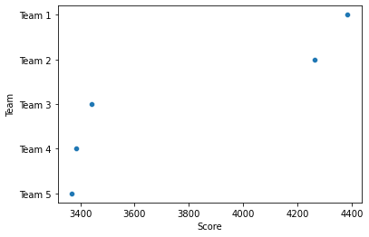

```python
sns.scatterplot(topteams['Score'],topteams['Team']);
```

**The above plot gives a clear visualization of the team that scored the maximum points.**

[output not shown]

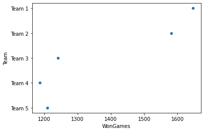

```python
sns.scatterplot(topteams['WonGames'],topteams['Team']);
```

[output not shown]

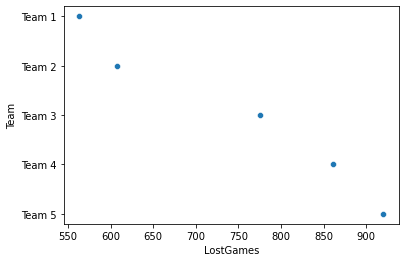

```python
sns.scatterplot(topteams['LostGames'],topteams['Team']);
```

#### Choosing teams which have scored more baskets than given baskets would be benefecial for the Company X.

We can see from this that all the teams have scored more baskets than they have given. These teams will be beneficial for ComapanyX

```python
topteams[topteams["BasketScored"] >= topteams["BasketGiven"]]
```

|  | Team | Tournament | Score | PlayedGames | WonGames | DrawnGames | LostGames | BasketScored | BasketGiven | TournamentChampion | Runner-up | TeamLaunch | HighestPositionHeld |
| --- | --- | --- | --- | --- | --- | --- | --- | --- | --- | --- | --- | --- | --- |
| 0 | Team 1 | 86 | 4385 | 2762 | 1647 | 552 | 563 | 5947 | 3140 | 33 | 23 | 1929 | 1 |
| 1 | Team 2 | 86 | 4262 | 2762 | 1581 | 573 | 608 | 5900 | 3114 | 25 | 25 | 1929 | 1 |
| 2 | Team 3 | 80 | 3442 | 2614 | 1241 | 598 | 775 | 4534 | 3309 | 10 | 8 | 1929 | 1 |
| 3 | Team 4 | 82 | 3386 | 2664 | 1187 | 616 | 861 | 4398 | 3469 | 6 | 6 | 1931 | 1 |
| 4 | Team 5 | 86 | 3368 | 2762 | 1209 | 633 | 920 | 4631 | 3700 | 8 | 7 | 1929 | 1 |

# Data Visualization

```python
sns.set_theme(style="whitegrid")
```

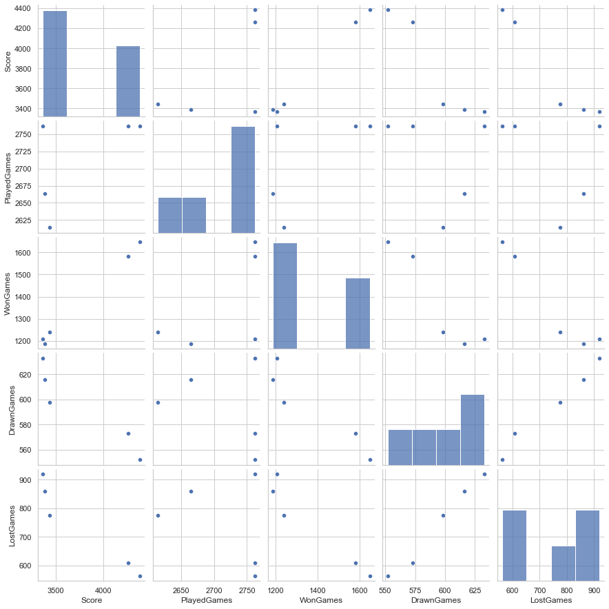

```python
sns.pairplot(topteams[["Score","PlayedGames", "WonGames",'DrawnGames','LostGames']]); #for the topteams database
```

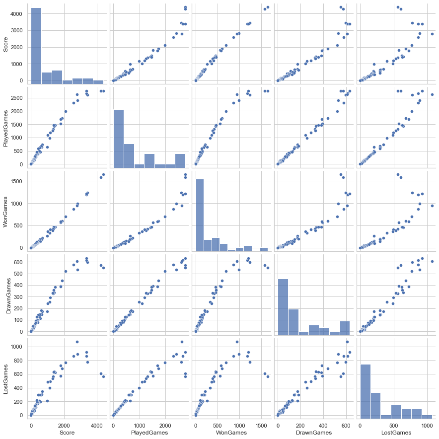

```python
sns.pairplot(basketball1[["Score","PlayedGames", "WonGames",'DrawnGames','LostGames']]); # orignal database basketball1
```

[output not shown]

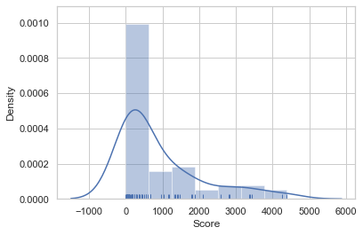

```python
sns.set_theme(style="whitegrid")
sns.distplot(basketball1['Score'], kde=True, rug=True);
```

[output not shown]

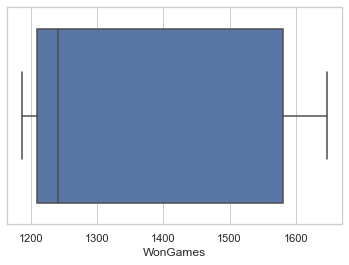

```python
sns.boxplot(topteams["WonGames"]);
```

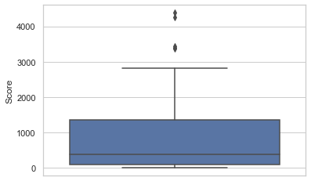

```python
sns.boxplot(y=basketball1['Score']); #using the orignal database basketball1
```

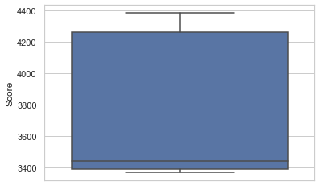

```python
sns.boxplot(y=topteams['Score']); #using the topteams database
```

#### From the above plot we can see that the scores have some outliers for the dataframe basketball1 and when we choose the top 30% scorers there are no outliers implying that these are the most competetive teams amongst given data.

#### We can see the correlation between all the parameters in the topteams database.

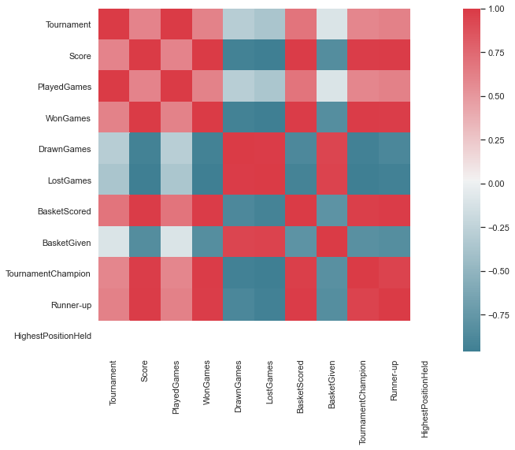

```python
f, ax = plt.subplots(figsize=(10, 8))
corr = topteams.corr()
sns.heatmap(corr, mask=np.zeros_like(corr, dtype=np.bool), cmap=sns.diverging_palette(220, 10, as_cmap=True),
            square=True, ax=ax)
```

## Conclusion:

we can see from the data that the top 5 teams to choose from the given data that will be beneficial for the CompanyX for managment will be the teams in the topteams database. ie **Team 1,2,3,4,5**

## 3. Please include any improvements or suggestions to the association management on quality, quantity, variety, velocity, veracity etc. on the data points collected by the association to perform a better data analysis in future.

Data given in this question does not have any information about team mates, knowing the composition of a team would be a major contributing factor to what team would have better chances at winning. Also, considering player costs would be a paramount factor for the Company to manage a team. If some player is highly valued then it may be a problem for the companyX.

# Part 3 - Project Based

**DOMAIN: Startup ecosystem**

**CONTEXT**: Company X is a EU online publisher focusing on the startups industry. The company specifically reports on the business related totechnology news, analysis of emerging trends and profiling of new tech businesses and products. Their event i.e. Startup Battlefield is the world’s pre-eminent startup competition. Startup Battlefield features 15-30 top early stage startups pitching top judges in front of a vast live audience, present in person and online.  
**DATA DESCRIPTION**: CompanyX_EU.csv - Each row in the dataset is a Start-up company and the columns describe the company.  
ATTRIBUTE INFORMATION:  
1. Startup: Name of the company  
2. Product: Actual product  
3. Funding: Funds raised by the company in USD  
4. Event: The event the company participated in  
5. Result: Described by Contestant, Finalist, Audience choice, Winner or Runner up  
6. OperatingState: Current status of the company, Operating ,Closed, Acquired or IPO  
Dataset has been downloaded from the internet. All the credit for the dataset goes to the original creator of the data.  
**PROJECT OBJECTIVE** : Analyse the data of the various companies from the given dataset and perform the tasks that are specified in the below steps. Draw insights from the various attributes that are present in the dataset, plot distributions, state hypotheses and draw conclusions from the dataset.

### Data Warehouse

: Read the CSV file.

```python
import numpy as np
import pandas as pd
import seaborn as sns
import matplotlib.pyplot as plt
sns.set_theme(style="whitegrid")
%matplotlib inline
```

```python
company = pd.read_csv('DS - Part3 - CompanyX_EU.csv')
```

### **Data Exploration** :

• Check the datatypes of each attribute.  
• Check for null values in the attributes.

```python
company.info()
```

```
<class 'pandas.core.frame.DataFrame'>
RangeIndex: 662 entries, 0 to 661
Data columns (total 6 columns):
 #   Column          Non-Null Count  Dtype
---  ------          --------------  -----
 0   Startup         662 non-null    object
 1   Product         656 non-null    object
 2   Funding         448 non-null    object
 3   Event           662 non-null    object
 4   Result          662 non-null    object
 5   OperatingState  662 non-null    object
dtypes: object(6)
memory usage: 31.2+ KB
```

```python
company.head(10)
```

|  | Startup | Product | Funding | Event | Result | OperatingState |
| --- | --- | --- | --- | --- | --- | --- |
| 0 | 2600Hz | 2600hz.com | NaN | Disrupt SF 2013 | Contestant | Operating |
| 1 | 3DLT | 3dlt.com | $630K | Disrupt NYC 2013 | Contestant | Closed |
| 2 | 3DPrinterOS | 3dprinteros.com | NaN | Disrupt SF 2016 | Contestant | Operating |
| 3 | 3Dprintler | 3dprintler.com | $1M | Disrupt NY 2016 | Audience choice | Operating |
| 4 | 42 Technologies | 42technologies.com | NaN | Disrupt NYC 2013 | Contestant | Operating |
| 5 | 5to1 | 5to1.com | $19.3M | TC50 2009 | Contestant | Acquired |
| 6 | 8 Securities | 8securities.com | $29M | Disrupt Beijing 2011 | Finalist | Operating |
| 7 | 8020 Media | 8020media.com | NaN | TC40 2007 | Contestant | Operating |
| 8 | About Last Night | aboutlastnight.net | NaN | Disrupt NYC 2012 | Contestant | Operating |
| 9 | Adgregate Markets | adgregate.com | NaN | TC50 2008 | Contestant | Operating |

```python
company.describe()
```

|  | Startup | Product | Funding | Event | Result | OperatingState |
| --- | --- | --- | --- | --- | --- | --- |
| count | 662 | 656 | 448 | 662 | 662 | 662 |
| unique | 662 | 656 | 240 | 26 | 5 | 4 |
| top | SnipSnap | shopgeniusapp.com | $1M | TC50 2008 | Contestant | Operating |
| freq | 1 | 1 | 17 | 52 | 488 | 465 |

```python
print(company.shape)
```

```
(662, 6)
```

```python
company.columns
```

```
Index(['Startup', 'Product', 'Funding', 'Event', 'Result', 'OperatingState'], dtype='object')
```

```python
company.isnull()
```

|  | Startup | Product | Funding | Event | Result | OperatingState |
| --- | --- | --- | --- | --- | --- | --- |
| 0 | False | False | True | False | False | False |
| 1 | False | False | False | False | False | False |
| 2 | False | False | True | False | False | False |
| 3 | False | False | False | False | False | False |
| 4 | False | False | True | False | False | False |
| ... | ... | ... | ... | ... | ... | ... |
| 657 | False | False | False | False | False | False |
| 658 | False | False | False | False | False | False |
| 659 | False | False | False | False | False | False |
| 660 | False | False | False | False | False | False |
| 661 | False | False | False | False | False | False |

662 rows × 6 columns

```python
company['Startup'].isnull().value_counts()
```

```
False    662
Name: Startup, dtype: int64
```

```python
print(company['Product'].isnull().value_counts())
```

```
False    656
True       6
Name: Product, dtype: int64
```

**From above query we can see that there are 6 products without a name in our dataset.**

```python
company['Funding'].isnull().value_counts()
```

```
False    448
True     214
Name: Funding, dtype: int64
```

**From above query we can see that there are 214 products without any mentioned funding in our dataset.**

```python
company['Event'].isnull().value_counts()
```

```
False    662
Name: Event, dtype: int64
```

```python
company['Result'].isnull().value_counts()
```

```
False    662
Name: Result, dtype: int64
```

```python
company['OperatingState'].isnull().value_counts()
```

```
False    662
Name: OperatingState, dtype: int64
```

```python
company['OperatingState'].value_counts()
```

```
Operating    465
Closed       106
Acquired      86
Ipo            5
Name: OperatingState, dtype: int64
```

```python
company['Event'].value_counts()
```

```
TC50 2008                    52
TC50 2009                    50
TC40 2007                    40
Disrupt NYC 2011             32
Disrupt NYC 2013             31
Disrupt SF 2013              31
Disrupt SF 2011              31
Disrupt NYC 2012             30
Disrupt SF 2012              30
Disrupt SF 2014              28
Disrupt SF 2015              27
Disrupt NYC 2014             27
Disrupt SF 2016              26
Disrupt NY 2015              26
Disrupt SF 2010              26
Disrupt NYC 2010             22
Disrupt NY 2016              22
Disrupt Beijing 2011         18
Hardware Battlefield 2015    15
Disrupt EU 2013              15
Disrupt EU 2014              15
Disrupt London 2015          15
Hardware Battlefield 2014    14
Hardware Battlefield 2016    13
-                            13
Disrupt London 2016          13
Name: Event, dtype: int64
```

**From this we can see that there are 13 entries without any Event mentioned.**

```python
company['Result'].value_counts()
```

```
Contestant         488
Finalist            84
Audience choice     41
Winner              26
Runner up           23
Name: Result, dtype: int64
```

```python
company['Funding'].value_counts()
```

```
$1M        17
$2M        12
$1.2M       9
$3M         9
$1.3M       9
           ..
$20.3K      1
$129.8K     1
$35.5M      1
$25.5M      1
$32.5M      1
Name: Funding, Length: 240, dtype: int64
```

### Data Preprocessing and Visualization:

**• Drop the null values.**  
From above we can see that the null values are present in the column **Product and Funding.**

```python
new_company = company.dropna(axis = 0, how ='any')
print("Old data frame length:", len(company), "\nNew data frame length:",
       len(new_company), "\nNumber of rows with at least 1 NA value: ",
       (len(company)-len(new_company)))
new_company.describe()
```

```
Old data frame length: 662
New data frame length: 446
Number of rows with at least 1 NA value:  216
```

|  | Startup | Product | Funding | Event | Result | OperatingState |
| --- | --- | --- | --- | --- | --- | --- |
| count | 446 | 446 | 446 | 446 | 446 | 446 |
| unique | 446 | 446 | 239 | 26 | 5 | 4 |
| top | Babelverse | shopgeniusapp.com | $1M | TC50 2008 | Contestant | Operating |
| freq | 1 | 1 | 17 | 31 | 312 | 319 |

**• Convert the ‘Funding’ features to a numerical value.**

```python
new_company['Funding']
```

```
1       $630K
3         $1M
5      $19.3M
6        $29M
10      $1.8M
        ...
657       $8M
658       $1M
659     $223M
660     $3.4M
661    $31.5M
Name: Funding, Length: 446, dtype: object
```

```python
df = new_company.copy()
```

```python
df['Funding'] = pd.to_numeric(df['Funding'].str.replace("$", ""), errors = "ignore")
df['Funding']
```

```
1       630K
3         1M
5      19.3M
6        29M
10      1.8M
       ...
657       8M
658       1M
659     223M
660     3.4M
661    31.5M
Name: Funding, Length: 446, dtype: object
```

```python
df['Funding'] = df['Funding'].replace({'K': '*1e3', 'M': '*1e6','B': '*1e9'},regex=True).map(pd.eval).astype(float)
df['Funding']
```

```
1         630000.0
3        1000000.0
5       19300000.0
6       29000000.0
10       1800000.0
          ...
657      8000000.0
658      1000000.0
659    223000000.0
660      3400000.0
661     31500000.0
Name: Funding, Length: 446, dtype: float64
```

```python
df.describe()
```

|  | Funding |
| --- | --- |
| count | 4.460000e+02 |
| mean | 1.724149e+07 |
| std | 9.048371e+07 |
| min | 5.000000e+03 |
| 25% | 7.452500e+05 |
| 50% | 2.200000e+06 |
| 75% | 9.475000e+06 |
| max | 1.700000e+09 |

**• Plot box plot for funds in million.**

```python
fundingM = df['Funding']/1000000
df['Funding_Million'] = fundingM
df.info()
df['Funding_Million']
```

```
<class 'pandas.core.frame.DataFrame'>
Int64Index: 446 entries, 1 to 661
Data columns (total 7 columns):
 #   Column           Non-Null Count  Dtype
---  ------           --------------  -----
 0   Startup          446 non-null    object
 1   Product          446 non-null    object
 2   Funding          446 non-null    float64
 3   Event            446 non-null    object
 4   Result           446 non-null    object
 5   OperatingState   446 non-null    object
 6   Funding_Million  446 non-null    float64
dtypes: float64(2), object(5)
memory usage: 27.9+ KB
```

```
1        0.63
3        1.00
5       19.30
6       29.00
10       1.80
        ...
657      8.00
658      1.00
659    223.00
660      3.40
661     31.50
Name: Funding_Million, Length: 446, dtype: float64
```

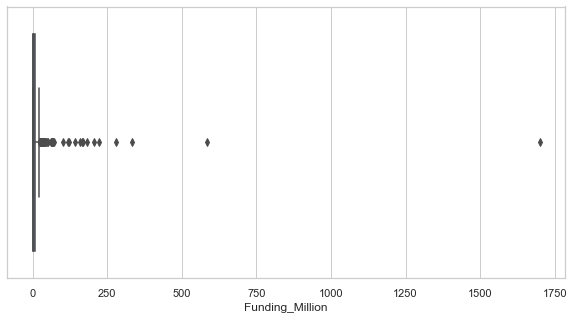

```python
fig_dims = (10,5)
fig, ax = plt.subplots(figsize=fig_dims)
sns.boxplot(x=df['Funding_Million'])
```

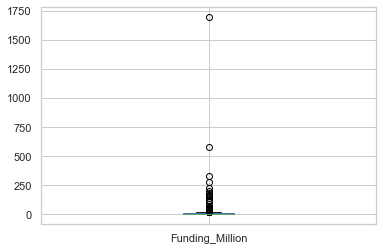

```python
df['Funding_Million'].plot.box();
```

**• Get the lower fence from the box plot.**

```python
sort_data = np.sort(df["Funding_Million"])
sort_data
Q1 = np.percentile(df["Funding_Million"], 25, interpolation = 'midpoint')
Q2 = np.percentile(df["Funding_Million"], 50, interpolation = 'midpoint')
Q3 = np.percentile(df["Funding_Million"], 75, interpolation = 'midpoint')

print('Q1 25 percentile of the given data is, ', Q1)
print('Q1 50 percentile of the given data is, ', Q2)
print('Q1 75 percentile of the given data is, ', Q3)

IQR = Q3 - Q1
low_fence = Q1 - 1.5 * IQR

print('Lower Fence is', low_fence)
```

```
Q1 25 percentile of the given data is,  0.7455
Q1 50 percentile of the given data is,  2.2
Q1 75 percentile of the given data is,  9.45
Lower Fence is -12.31125
```

**• Check number of outliers greater than upper fence.**

```python
up_fence = Q3 + 1.5 * IQR
print('Upper Fence is', up_fence.round(4))
outlier =[]
for x in df["Funding_Million"]:
    if ((x> up_fence)):
         outlier.append(x)
#print('outlier in the dataset is', outlier)

print("Number of outliers greater than upper fence are",len(outlier))
```

```
Upper Fence is 22.5067
Number of outliers greater than upper fence are 60
```

**• Drop the values that are greater than upper fence.**

```python
df_no_outliers = df[df["Funding_Million"] < up_fence]
df_no_outliers.describe()
```

|  | Funding | Funding_Million |
| --- | --- | --- |
| count | 3.860000e+02 | 386.00000 |
| mean | 3.725140e+06 | 3.72514 |
| std | 4.732360e+06 | 4.73236 |
| min | 5.000000e+03 | 0.00500 |
| 25% | 6.000000e+05 | 0.60000 |
| 50% | 1.700000e+06 | 1.70000 |
| 75% | 5.000000e+06 | 5.00000 |
| max | 2.200000e+07 | 22.00000 |

**• Plot the box plot after dropping the values.**

[output not shown]

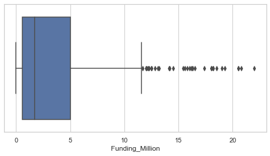

```python
fig_dims = (8,4)
fig, ax = plt.subplots(figsize=fig_dims)
sns.boxplot(df_no_outliers["Funding_Million"])
```

**• Check frequency of the OperatingState features classes.**

```python
company['OperatingState'].value_counts()
```

```
Operating    465
Closed       106
Acquired      86
Ipo            5
Name: OperatingState, dtype: int64
```

**• Plot a distribution plot for Funds in million.**

[output not shown]

[figure not shown]

```python
plt.title('Boxplot of funds with the original outliers')
plt.ylabel("Funds raised (in Million)")
sns.distplot(df['Funding_Million']); #distribution plot for Funds in Million with the outliers.
```

[output not shown]

[figure not shown]

```python
plt.title('Boxplot of funds without the original outliers')
plt.ylabel("Funds raised (in Million)")
sns.distplot(df_no_outliers['Funding_Million']); ##distribution plot for Funds in Million without the outliers.
```

**• Plot distribution plots for companies still operating and companies that closed.**

[output not shown]

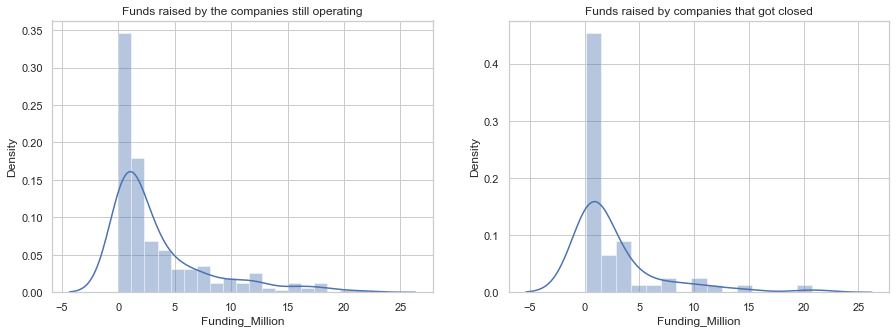

```python
fig, ax = plt.subplots(1, 2)

fig.set_figheight(5)
fig.set_figwidth(15)

sns.distplot(df_no_outliers.loc[df_no_outliers.OperatingState == 'Operating', 'Funding_Million'], ax = ax[0])
sns.distplot(df_no_outliers.loc[df_no_outliers.OperatingState =='Closed', 'Funding_Million'], ax = ax[1])

ax[0].set_title('Funds raised by the companies still operating')
ax[1].set_title('Funds raised by companies that got closed')
plt.show()
```

[output not shown]

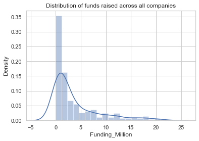

```python
sns.distplot(df_no_outliers.Funding_Million)
plt.title('Distribution of funds raised across all companies')
plt.show()
```

### Statistical Analysis

**• Is there any significant difference between Funds raised by companies that are still operating vs companies that closed down?**  
1. Write the null hypothesis and alternative hypothesis.  
2. Test for significance and conclusion.

```python
df_no_outliers.Funding_Million.describe()
```

```
count    386.00000
mean       3.72514
std        4.73236
min        0.00500
25%        0.60000
50%        1.70000
75%        5.00000
max       22.00000
Name: Funding_Million, dtype: float64
```

- 75% of the companies have less than 5 million raised funds, the max however is 22
- Even after removing the outliers, the data is pretty heavily skewed

**Null hypothesis (Ho)** : There is no difference between the two means.  
**Alternate hypothesis (Ha)** : There is significant difference between the two means.

```python
from statsmodels.stats.weightstats import ztest

sample1 = df_no_outliers.loc[df_no_outliers.OperatingState == 'Operating', 'Funding_Million']
sample2 = df_no_outliers.loc[df_no_outliers.OperatingState =='Closed', 'Funding_Million']

alpha = 0.05   # Let's consider a significance level of 5%

test_statistic, p_value = ztest(sample1, sample2)

if p_value <= alpha:
    print(f'Since the p-value, {round(p_value, 3)} < {alpha} (alpha) the difference is significant and we reject the Null hypothesis')
else:
    print(f'''\t Since the p-value, {round(p_value,3)} > {alpha} (alpha) the difference is not significant and,
    \t we fail to reject the Null hypothesis''')
```

```
	 Since the p-value, 0.192 > 0.05 (alpha) the difference is not significant and,
    	 we fail to reject the Null hypothesis
```

From the test we have found no evidence to state that there is any significant difference between funds raised by the companies that are still operting and those that have closed down.  
**Conclusion**: The amount of funds a company raises is not a significant factor in deciding if the company will remain operational or close down.

**• Make a copy of the original data frame.**

```python
df2 = company.copy(deep = True)
df2.head()
```

|  | Startup | Product | Funding | Event | Result | OperatingState |
| --- | --- | --- | --- | --- | --- | --- |
| 0 | 2600Hz | 2600hz.com | NaN | Disrupt SF 2013 | Contestant | Operating |
| 1 | 3DLT | 3dlt.com | $630K | Disrupt NYC 2013 | Contestant | Closed |
| 2 | 3DPrinterOS | 3dprinteros.com | NaN | Disrupt SF 2016 | Contestant | Operating |
| 3 | 3Dprintler | 3dprintler.com | $1M | Disrupt NY 2016 | Audience choice | Operating |
| 4 | 42 Technologies | 42technologies.com | NaN | Disrupt NYC 2013 | Contestant | Operating |

**• Check frequency distribution of Result variable.**

```python
df2.Result.value_counts()
```

```
Contestant         488
Finalist            84
Audience choice     41
Winner              26
Runner up           23
Name: Result, dtype: int64
```

**• Calculate percentage of winners that are still operating and percentage of contestants that are still operating.**

```python
winners = df2.Result.value_counts()[1:].sum()
print("Total number of teams that either won or were runner up or Audience Choice or Finalist=",winners)
contestants = df2.Result.value_counts()['Contestant']
print("Total number of teams that are contestants=",contestants)
```

```
Total number of teams that either won or were runner up or Audience Choice or Finalist= 174
Total number of teams that are contestants= 488
```

```python
contestants_operating = df2.OperatingState[df2.Result == 'Contestant'].value_counts().loc['Operating']
winners_operating = df2.OperatingState[df2.Result != 'Contestant'].value_counts().loc['Operating']
print("Contestants that are still operating =",contestants_operating)
print("Winners that are still operating =",winners_operating)
```

```
Contestants that are still operating = 332
Winners that are still operating = 133
```

```python
print("Percentage of winners that are operating = ",winners_operating/winners*100,"%")
print("Percentage of Contestants that are operating = ",contestants_operating/contestants*100,"%")
```

```
Percentage of winners that are operating =  76.4367816091954 %
Percentage of Contestants that are operating =  68.0327868852459 %
```

**• Write your hypothesis comparing the proportion of companies that are operating between winners and contestants:**  
1.Write the null hypothesis and alternative hypothesis.  
2.Test for significance and conclusion

**Null hyputhesis (Ho)**: The proportion of companies that are operating is the same in both categories - winners and contestants

**Alternative hypothesis (Ha)**: The proportion of companies that are operating is significantly different from each other, among the two categories

```python
from statsmodels.stats.proportion import proportions_ztest

test_statistic, p_value = proportions_ztest([contestants_operating, winners_operating], [contestants, winners])

if p_value <= alpha:
    print(f'Since the p-value, {round(p_value, 3)} < {alpha} (alpha) the difference is significant and we reject the Null hypothesis')
else:
    print(f'''\t Since the p-value, {round(p_value,3)} > {alpha} (alpha) the difference is not significant and,
    \t we fail to reject the Null hypothesis''')
```

```
Since the p-value, 0.037 < 0.05 (alpha) the difference is significant and we reject the Null hypothesis
```

**Conclusion** : Since we reject the null hypothesis, we can say that the Companies that are among the winners remain more operational than the companies that are just participants

**• Check distribution of the Event variable.**

```python
df2['Event'].value_counts()
```

```
TC50 2008                    52
TC50 2009                    50
TC40 2007                    40
Disrupt NYC 2011             32
Disrupt NYC 2013             31
Disrupt SF 2013              31
Disrupt SF 2011              31
Disrupt NYC 2012             30
Disrupt SF 2012              30
Disrupt SF 2014              28
Disrupt SF 2015              27
Disrupt NYC 2014             27
Disrupt SF 2016              26
Disrupt NY 2015              26
Disrupt SF 2010              26
Disrupt NYC 2010             22
Disrupt NY 2016              22
Disrupt Beijing 2011         18
Hardware Battlefield 2015    15
Disrupt EU 2013              15
Disrupt EU 2014              15
Disrupt London 2015          15
Hardware Battlefield 2014    14
Hardware Battlefield 2016    13
-                            13
Disrupt London 2016          13
Name: Event, dtype: int64
```

**• Select only the Event that has disrupt keyword from 2013 onwards.**

```python
events = df_no_outliers[df_no_outliers.Event.apply(lambda x: 'Disrupt' in x and int(x[-4:]) > 2012)].Event  # all the events of relevance
events
```

```
1         Disrupt NYC 2013
3          Disrupt NY 2016
13         Disrupt SF 2015
14     Disrupt London 2016
16         Disrupt SF 2015
              ...
635        Disrupt NY 2015
641       Disrupt NYC 2013
642        Disrupt SF 2014
646    Disrupt London 2015
660        Disrupt SF 2013
Name: Event, Length: 185, dtype: object
```

**• Write and perform your hypothesis along with significance test comparing the funds raised by companies across NY, SF and EU events from 2013 onwards.**

```python
NY_events = df_no_outliers.loc[events[events.apply(lambda x: 'NY' in x)].index, 'Funding_Million']
SF_events = df_no_outliers.loc[events[events.apply(lambda x: 'SF' in x)].index, 'Funding_Million']
EU_events = df_no_outliers.loc[events[events.apply(lambda x: 'EU' in x or 'London' in x)].index, 'Funding_Million']
print(len(NY_events), len(SF_events), len(EU_events))
```

```
71 74 40
```

**Null Hypothesis(Ho)**: Average funds raised by companies across three cities are the same

**Alternative Hypothesis(Ha)**: Average funds raised by companies across three cities are the different

```python
from scipy.stats import f_oneway


stat, p_value = f_oneway(NY_events, SF_events, EU_events)

if p_value <= alpha:
    print(f'Since the p-value, {round(p_value, 3)} < {alpha} (alpha) the difference is significant and we reject the Null hypothesis')
else:
    print(f'''\t Since the p-value, {round(p_value,3)} > {alpha} (alpha) the difference is not significant and,
    \t we fail to reject the Null hypothesis''')
```

```
	 Since the p-value, 0.628 > 0.05 (alpha) the difference is not significant and,
    	 we fail to reject the Null hypothesis
```

**• Plot the distribution plot comparing the 3 city events.**

[output not shown]

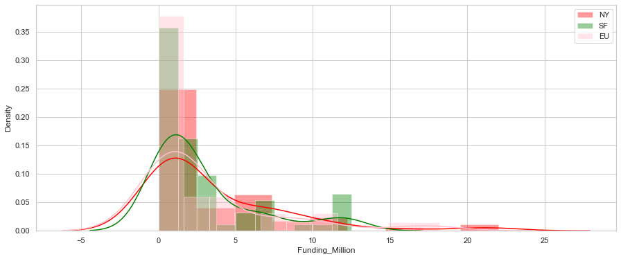

```python
plt.figure(figsize=(15,6))
sns.distplot(NY_events, color = 'Red', label = 'NY')
sns.distplot(SF_events, color = 'Green', label = 'SF')
sns.distplot(EU_events, color = 'pink', label = 'EU')
plt.legend()
plt.show()
```

The distribution of funds raised by the companies across the three regions is the same  
We found no evidence to say companies participating in certain regions have funds either significantly on the higher side or on the lower side

## Write your observations on improvements or suggestions on quality, quantity, variety, velocity, veracity etc. on the data points collected to perform a better data analysis.

For better analysis of the data we can have information about various other parameters related to a startup company, ie how many employees they have, feedback from employee in terms of job satisfactionn, also information with regard to the sectors they operate in will let the data be segregated in specific domains and give a deeper understanding of the startup's in each sector. Thus providing better results even for the competiton .